# Introduction to Git and GitLab

Version control for your research, hands-on on Eddie

Graeme Grimes

## Today’s plan

1. Why version control?
2. Configuring Git
3. Recording changes locally
4. Working with remotes (GitLab)
5. Git in RStudio on Noteable
6. Collaborating
7. Exploring history
8. Ignoring things
9. Branching & tagging
10. Wrap up

Rough timetable: break **11:00** · lunch **12:30** · restart **13:30** · finish **16:00**. Keep a terminal logged in to Eddie open alongside the slides.

## Before we start

- Logged in to **Eddie**: `ssh <UUN>@eddie.ecdf.ed.ac.uk`
- On an interactive node: `qlogin`
- `git --version` prints a version number
- Logged in to **GitLab**: https://git.ecdf.ed.ac.uk
- Logged in to **Noteable** and can start **RStudio**

**Sticky notes**

**Green**: I’m done / all good

**Red**: I’m stuck, please come over

Stick it on your laptop lid. Every exercise slide has a reminder at the bottom.

## Join the Wooclap

1. On your **phone** or laptop, go to **wooclap.com**
2. Enter the event code:

No account needed. Keep the tab open: we’ll use it for the quiz questions all day.

none

## Warm-up

Answer on Wooclap · Q1–Q2 · XXXXXX

**Q1.** How comfortable are you with the **command line**?

1 = never used it · 5 = live in it

**Q2.** One **word** that comes to mind when you hear *“version control”*

## Wooclap Q1–Q2 · live

# Why Version Control?

Episode 01

What problem does version control solve, and when should I use Git?

## Sound familiar?

- `report.docx`
- `report_final.docx`
- `report_final_v2.docx`
- `report_final_for_real_this_time.docx`
- `report_final_sent_to_boss.docx`

*“I wish I could go back to the version I had yesterday, before I deleted that paragraph.”*

Version control is designed to solve exactly this.

## What is Git?

A **version control system**: a dated, permanent record of every meaningful change to your project. Think of it as a **lab book for code**.

Not just for source code:

- configuration files and parameter sets
- small data files (git lfs for large ones)
- documentation, papers, book chapters

Other systems exist (SVN, Mercurial, …) but Git is by far the most widely used.

## Why use it?

- **Keep files in sync** across your laptop, work PC and **Eddie**
- **Provenance**: who changed what, when, and why?
- **Back up** precious work, and recover deleted files
- **Reproduce** the exact state of your code when you published a paper
- **Collaborate** safely with colleagues
- **Show off** your work, and take it with you when you change jobs

## The Git workflow

Working directory README.md `git add` → Staging area README.md `git commit` → Repository README.md

You **edit** a file. Git notices it has changed…

## The Git workflow

Working directory README.md `git add` → Staging area README.md `git commit` → Repository README.md

…`git add` puts it in the **staging area**: “this goes in the next snapshot”…

## The Git workflow

Working directory README.md `git add` → Staging area README.md `git commit` → Repository README.md

- **Working directory**: the files you edit
- **Staging area**: a “waiting room” where you choose what goes into the next snapshot
- **Repository**: the permanent history of every snapshot (commit)

**edit → stage → commit.** You only need a handful of commands today.

## Your turn: why bother?

Answer on Wooclap · Q3 · XXXXXX

Which of these is **not** a typical reason to use version control?

A. Keeping files synchronised between two laptops  
B. Tracking the history of code changes  
C. Encrypting files to keep them secret  
D. Collaborating with colleagues on a shared project

**C.** Encryption is possible, but it is not what a version control system is for.

## Wooclap Q3 · live

# Configuring Git

Episode 02

How does Git know who I am, and which settings should I change right away?

## Log in to Eddie

```bash
ssh <UUN>@eddie.ecdf.ed.ac.uk
qlogin
git --version
```

Run everything today on an interactive node (`qlogin`), not the login node.

## Three levels of configuration

| Level | File | Scope |
| --- | --- | --- |
| System | `/etc/gitconfig` | Every user on the machine |
| **Global** | `~/.gitconfig` | All repositories for **you** |
| Local | `.git/config` | A single repository |

Git looks **local → global → system**: the closest level wins.

## Tell Git who you are

```bash
git config --global user.name "Your Name"
git config --global user.email "you@ed.ac.uk"
```

Only needed **once per machine**. Every commit you make is stamped with this name and email.

⚠️ Your commit email becomes part of the public history of any repository you publish. Consider a “no-reply” address on public platforms.

## Sensible defaults

```bash
git config --global init.defaultBranch main   # name the first branch "main"
git config --global color.ui auto             # colour output
git config --global core.editor "nano -w"     # editor for commit messages
git config --global help.autocorrect 1        # run the closest command after 0.1 s
git config --global pull.rebase false         # git pull merges (today's default)
```

Older Git calls the first branch `master`. Setting `init.defaultBranch` keeps everything consistent with today’s commands.

## Your turn: check your settings

Run `git config --global --list`, then `cat ~/.gitconfig`.

Which **section header** (`[user]`, `[core]`, …) does each setting live under?

`[user]` name, email · `[core]` editor · `[color]` ui · `[init]` defaultBranch · `[help]` autocorrect · `[pull]` rebase

## Your turn: predict the result

Answer on Wooclap · Q4 · XXXXXX

- System: `user.email = root@machine`
- Global: *not set*
- Local: `user.email = user@project`

Which email is recorded when you commit **inside** the project? And in a **different** repository?

Inside the project: **user@project** (local wins). Anywhere else: **root@machine** (falls back to system).

## Wooclap Q4 · live

# Recording Changes Locally

Episode 03

How do I create a repository and record snapshots of my work?

## Create a repository

```bash
mkdir MyProject
cd MyProject
git init
git status
```

```
On branch main

No commits yet

nothing to commit (create/copy files and use "git add" to track)
```

`git init` creates a hidden `.git` folder that stores all future history.

## File states

**Untracked**: Git doesn’t know about it yet

**Modified**: changed since the last commit

**Staged**: added, ready for the next commit

**Committed**: safely in the history

untracked / modified `git add` ↓ staged `git commit` ↓ committed

## Add a README

```bash
echo "# My eddie Python project" > README.md
git status
```

```
Untracked files:
  (use "git add <file>..." to include in what will be committed)
    README.md
```

```bash
git add README.md
git status
```

```
Changes to be committed:
  (use "git rm --cached <file>..." to unstage)
    new file:   README.md
```

## Commit the snapshot

```bash
git commit -m "initial commit"
```

```
[main (root-commit) 72041c0] initial commit
 1 file changed, 1 insertion(+)
 create mode 100644 README.md
```

Every commit gets a unique **hash**, shown here as `72041c0`.

**Good commit messages**

- Subject line **≤ 50 characters**
- **Imperative mood**: “Add”, not “Added” or “Adds”
- **Specific**: “Add error handling for login”, not “Update code”

## Look at the history

```bash
git log
```

```
commit 72041c0b39884a9bf978bc272c82d862976abcb (HEAD -> main)
Author: firstname surname <emailaddress@ed.ac.uk>
Date:   Tue Sep 24 10:06:58 2024 +0100

    initial commit
```

`HEAD` is a pointer to **where you are** in the history.

```bash
git log --oneline
```

```
72041c0 (HEAD -> main) initial commit
```

## Make a change

```bash
nano README.md
```

```
# My eddie Python project

To run Python on eddie need to run:
module load igmm/apps/python/3.12.3
```

```bash
git status
```

```
Changes not staged for commit:
    modified:   README.md
```

## What changed? `git diff`

```bash
git diff README.md
```

```
diff --git a/README.md b/README.md
index a4c6c69..603f621 100644
--- a/README.md
+++ b/README.md
@@ -1 +1,4 @@
 # My eddie Python project
+
+To run Python on eddie need to run:
+module load igmm/apps/python/3.12.3
```

## Anatomy of a diff

| Part | What it means |
| --- | --- |
| `diff --git a/README.md b/README.md` | the file being compared: **a/** = old version, **b/** = new version |
| `index a4c6c69..603f621 100644` | short IDs of the old and new file contents, then the file mode (normal file) |
| `--- a/README.md` | lines from the **old** version are marked with `-` |
| `+++ b/README.md` | lines from the **new** version are marked with `+` |
| `@@ -1 +1,4 @@` | a *hunk* header: old starts at line 1 (1 line), new starts at line 1 (4 lines) |
| `# My eddie…` | a leading **space**: unchanged context line |
| `+module load…` | a leading **`+`**: line added |
| `-module load…` | a leading **`-`**: line removed |

An edited line shows up as a `-` line (old text) followed by a `+` line (new text).

## Stage, commit, compare

```bash
git add README.md
git commit -m "Describe how to run Python on eddie"
git diff HEAD~1 README.md     # compare with one commit ago
```

| Command | Compares |
| --- | --- |
| `git diff` | working directory ↔︎ staging area |
| `git diff --staged` | staging area ↔︎ last commit |
| `git diff HEAD` | working directory ↔︎ last commit |
| `git diff HEAD~1` | now ↔︎ one commit ago |

## Undoing changes

```bash
git restore README.md           # discard unstaged edits
git restore --staged README.md  # unstage, keep the edits
```

Older Git: `git checkout -- README.md`

⚠️ `git restore` **permanently** discards edits that were never staged or committed.

## Directories and data

Git tracks **files**, not empty directories:

```bash
mkdir Src
touch Src/.gitkeep
git add Src/.gitkeep
```

Add a small dataset:

```bash
mkdir Data
cp /exports/igmm/software-rl9/bac/dataWranglingGenomics/20230529/workshop_data/combined_tidy_vcf.csv Data/data.csv
git add Data/data.csv
git commit -m "Add example dataset"
```

Small, stable data is fine to commit. Large or sensitive data: see *Ignoring Things*.

## Your turn: a Python script

1. Create `Src/hello.py`, then add and commit it:

```python
#!/usr/bin/env python
print("Hello World!")
```

2. Change it to read the CSV and print the number of rows. Check `git diff` before you commit.

```python
#!/usr/bin/env python
import pandas as pd

variants = pd.read_csv("Data/data.csv")
print(len(variants))
```

`git diff Src/hello.py` → `git add Src/hello.py` → `git commit -m "Read CSV and report row count"`

# Working with Remotes

Episode 04

How do I connect my repository to GitLab, and push and pull changes?

## What is a remote?

A **remote** is a saved link to another copy of your repository, usually on a server.

It lets you **share** your history and **collaborate**.

Hosting services:

- **University GitLab**: https://git.ecdf.ed.ac.uk
- GitHub, gitlab.com, Bitbucket, …

Remote (GitLab) `git push` ↑ ↓ `git pull` Local (Eddie)

## Create a GitLab project

[figure not shown]

1. Log in to https://git.ecdf.ed.ac.uk
2. **New project** → **Create blank project**
3. Project name: **MyProject**
4. **Untick** *Initialize repository with a README*
5. **Create project**

## An empty repository

[figure not shown]

GitLab shows the commands for pushing an existing repository. We’ll use the SSH address.

## SSH keys: password-less access

Eddie has **already made a key** for you:

```bash
[username@login02(eddie) ~]$ cat ~/.ssh/id_alcescluster.pub
```

- `~/.ssh/id_alcescluster`: **private** key. Never share it!
- `~/.ssh/id_alcescluster.pub`: **public** key. Paste this into GitLab.

User icon > Preferences > Access > SSH Keys > Add new key

Test it: `ssh -T git@git.ecdf.ed.ac.uk` → *“Welcome to GitLab”*

Don’t make a new key with `ssh-keygen`: Eddie’s `~/.ssh/config` tells SSH to use `id_alcescluster` for every server, so a new `id_ed25519` is never offered to GitLab.

## Connect and push

```bash
git remote add origin git@git.ecdf.ed.ac.uk:<username>/myproject.git
git remote -v
git push -u origin main
```

- `origin` is the conventional name for your main remote
- `-u` sets up **tracking**: after this, plain `git push` and `git pull` just work

Forget `-u` on your first push and Git will complain there is “no upstream branch”.

## Pushed!

[figure not shown]

## Sync a change

Add a **Data** section to `README.md` on Eddie:

```
## Data
The [data](https://figshare.com/articles/dataset/Data_Carpentry_Genomics_beta_2_0/7726454?file=14632895)
is made available under a [Creative Commons license](https://creativecommons.org/licenses/by/3.0/).
```

```bash
git add README.md
git commit -m "Add Data section"
git push
```

Refresh GitLab: the rendered README shows your new section.

## Pull, fetch and rejected pushes

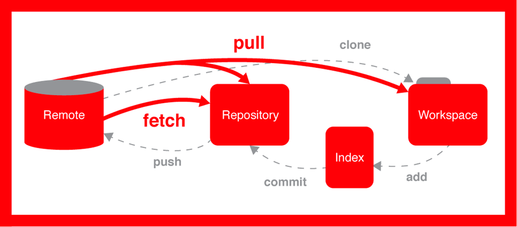

- `git fetch`: download changes, don’t touch your files
- `git pull` = `git fetch` + `git merge`

```
! [rejected]   main -> main (non-fast-forward)
```

Your branch is **behind** → `git pull`, resolve any conflicts, then `git push` again.

## Your turn: remotes

1. Run `git remote -v`. What do you see?
2. What command shows which remote branch your local `main` is tracking?
1. The **fetch** and **push** URLs for `origin`.
2. `git branch -vv` lists local branches with their upstream counterparts.

# Git in RStudio

Episode 05

How can I use Git through a graphical interface on Noteable?

## Why a GUI?

- A visual alternative to typing commands
- Easier to **see** changes and history
- Most IDEs (RStudio, VS Code) have Git built in
- **Same Git underneath**: every button runs a shell command

Noteable: https://noteable.edina.ac.uk/login

[figure not shown]

## Configure Git on Noteable

A new machine needs its own Git configuration. In RStudio’s **Terminal** pane:

```bash
git config --global user.name "Your Name"
git config --global user.email "you@ed.ac.uk"
pip install pandas      # needed for our script
```

## Clone with RStudio

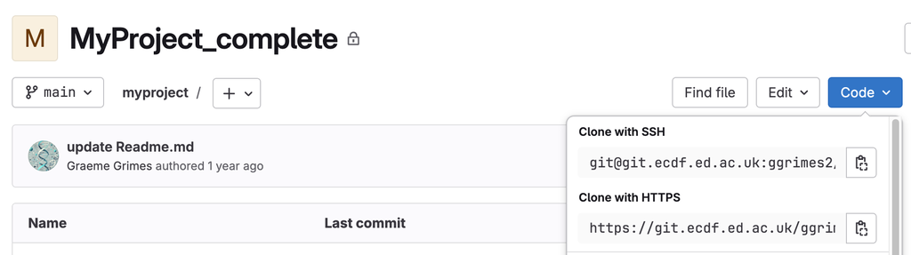

[figure not shown]

1. On GitLab: **Code** → copy **Clone with HTTPS**
2. RStudio: File > New Project > Version Control > Git
3. Paste the URL, choose a folder
4. **Create Project**

The **Git** pane appears top-right.

## Commit and push from RStudio

1. Edit `README.md` and save
2. **Git** pane → tick the file to **stage** it
3. **Commit** → write a message → **Commit**
4. **Push** ↑

Check GitLab: **Repository → Commits** shows your message.

## Your turn: round trip

1. On **Noteable**: edit `Src/hello.py`, commit and **push**.
2. On **Eddie**: `git pull`. Is the change there?
3. On **Eddie**: add a *Using Noteable* section to the README, commit and push.
4. On **Noteable**: **Pull** ↓

Both copies stay in sync through GitLab: **commit → push** on one machine, **pull** on the other. Always pull before you start work!

# Collaborating

Episode 06

How do I work on the same repository as a colleague?

## Models for collaboration

- **Shared repository**: give collaborators direct access. Quick, but needs **trust**.
- **Fork and merge request**: a collaborator copies (forks) your repo, changes it, and asks you to merge. Common in open source.

Today: **shared repository** in pairs.

Break into pairs · Person 1 gets Person 2’s UUN

## Person 1: add a member

[figure not shown]

1. Project > Members
2. **Invite members**
3. Enter Person 2’s **UUN**
4. Role: **Developer**
5. Check the members list

## Person 1: unprotect `main`

[figure not shown]

By default GitLab only lets **Maintainers** push to `main`.

Settings > Repository > Protected branches

Click **Unprotect** next to `main`.

## Person 2: clone, change, push

```bash
git clone https://git.ecdf.ed.ac.uk/<person1>/myproject.git project-collab
cd project-collab
git blame README.md          # who last changed each line?
nano README.md
git add README.md
git commit -m "Update README with message from Person 2"
git push
```

**Rejected?** Your copy is behind: `git pull`, then `git push` again.

## How a conflict happens

[figure not shown]

Git merges changes to **different** lines automatically. Only the **same line** changed two ways needs you to decide.

## Merge conflicts

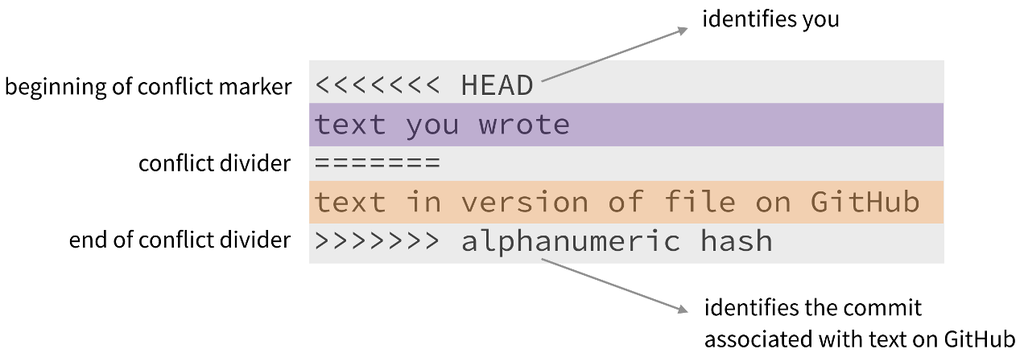

Edit the file to keep what you want, **delete the markers**, then:

```bash
git add README.md
git commit -m "Resolve conflict in README"
git push
```

## Your turn: make a conflict

Both partners edit the **same line** of `README.md` and commit.

Person 1 pushes first. Person 2 then pushes.

What happens, and how do you fix it?

Person 2’s push is **rejected**. `git pull` reports a **conflict**; open the file, choose the text to keep, remove the `<<<<<<<` `=======` `>>>>>>>` markers, then `add` → `commit` → `push`.

## Forking & caching credentials

**Fork**

Click **Fork** on a project page to get your own copy on GitLab, e.g. https://git.ecdf.ed.ac.uk/ggrimes2/git4igc

**Tired of typing your password?**

```bash
git config --global \
  credential.helper 'cache --timeout=3600'
```

Caches credentials for one hour.

# Exploring History

Episode 07

How can I find out what changed, when, and by whom, and how do I undo mistakes?

## `git log`

```bash
git log                              # full history
git log --oneline                    # one line per commit
git log --graph --oneline --decorate # branches and merges
git log -p README.md                 # changes to one file
git log --author="Your Name"         # one person's commits
```

## `git show` and `git diff`

```bash
git show a3f2d4e              # message, author and changes in one commit
git show HEAD~2:README.md     # a file as it was two commits ago
git diff abc123 def456        # between two commits
git diff HEAD~1 HEAD README.md
```

`HEAD~N` = *N commits before* where you are now.

## Going back

```bash
git restore README.md                       # discard unstaged edits
git restore --staged README.md              # unstage
git restore --source=HEAD~1 README.md       # file from an earlier commit
```

In RStudio: **Git** pane → **History** shows the same log graphically.

```bash
git blame README.md      # who last changed each line
```

## Oops! Undoing mistakes

| Situation | Fix |
| --- | --- |
| Typo in the last commit message | `git commit --amend -m "Better message"` |
| Forgot a file in the last commit | `git add forgotten.py` → `git commit --amend --no-edit` |
| A bad commit is **already pushed** | `git revert <hash>`: a *new* commit that undoes it |
| Half-done edits, but need to `git pull` | `git stash` → `git pull` → `git stash pop` |
| Deleted or broke a file (not committed) | `git restore <file>` |

**Golden rule:** only `--amend` commits you have **not pushed** yet. Once something is on GitLab, use `git revert`, which adds history instead of rewriting it.

## `revert` and `stash` in action

```bash
git revert HEAD --no-edit
git log --oneline
```

```
b7e1f02 Revert "Add Data section"
9c2a1d4 Add Data section
72041c0 initial commit
```

The mistake stays in the history, along with its fix.

```bash
git stash          # put edits aside
git pull           # now safe to pull
git stash pop      # edits come back
git stash list
```

A stash is a clipboard for uncommitted work.

## Your turn: undo it

1. Add a silly line to `README.md` and commit it with the message `"oops"`.
2. Fix the message to `"Add silly line"` **without** a new commit.
3. Push, then undo the whole commit **safely**.

```bash
git commit --amend -m "Add silly line"   # before pushing: rewrite is fine
git push
git revert HEAD --no-edit                # after pushing: add an undo commit
git push
```

## Your turn: `git diff HEAD`

Answer on Wooclap · Q5 · XXXXXX

What does `git diff HEAD` show?

1. working directory ↔︎ staging area
2. staging area ↔︎ last commit
3. working directory ↔︎ last commit
4. two different commits

**c)**. `git diff HEAD` shows everything that has changed since the last commit, staged or not.

## Wooclap Q5 · live

## Your turn: the archaeologist

Find the **very first version** of `README.md`.

*Hint:* combine a commit hash and a filename in `git show`.

```bash
git log --oneline        # oldest commit is at the bottom
git show 72041c0:README.md
```

# Ignoring Things

Episode 08

How do I stop Git tracking files I don’t want in the repository?

## `.gitignore`

Files you usually **don’t** want to track:

- temporary files from your editor or IDE
- outputs you can regenerate
- large data or binary files
- anything **sensitive**: passwords, keys, patient data

```bash
nano .gitignore
```

```
.Rhistory
.RData
.Rproj.user/
results/
*.dat
```

## Large data on Eddie

- Git keeps **every version forever**: commit a 20 GB BAM once and it stays in `.git` even after you delete it
- GitLab has **size limits**: big pushes get rejected
- Commit the **scripts** and a README that says **where the data lives** on Eddie / DataStore
- Check how big your repository is: `du -sh .git`

```
# .gitignore for genomics
*.bam
*.bai
*.cram
*.fastq.gz
*.vcf.gz
results/
work/
```

Already committed a big file? `git rm --cached big.bam` stops tracking it, but it is **still in the history**. Ask for help **before** you push.

## Commit it, and a gotcha

```bash
git add .gitignore
git commit -m "Ignore temporary and output files"
```

⚠️ `.gitignore` only affects **untracked** files. To stop tracking a file you already committed:

```bash
git rm --cached filename
```

Ignore on your machine only, without sharing: add patterns to `.git/info/exclude`.

## Your turn: ignore a secret

1. Create `secret.txt` containing some text.
2. Add it to `.gitignore`.
3. Run `git status`. Is it listed?
4. Commit your `.gitignore`.

```bash
echo "my password" > secret.txt
echo "secret.txt" >> .gitignore
git status        # secret.txt no longer appears
git add .gitignore
git commit -m "Add gitignore to exclude secret.txt"
```

# Branching & Tagging

Episode 09

How do I develop in parallel, and mark important versions?

## Why branch?

- **Test a change** without breaking the working version
- **Collaborate** without editing the same code at the same time
- Keep an **experiment** separate until it’s worth keeping

A branch is a **label pointing to a commit** that moves forward as you commit. Creating one is instant: nothing is copied.

## Create and switch

```bash
git branch             # list branches: * marks the current one
git branch dev         # create dev
git switch dev         # move to it (older Git: git checkout dev)
```

```
* dev
  main
```

Create and switch in one step: `git switch -c dev`

## Commit on a branch

```bash
nano Src/summary.py
git add Src/summary.py
git commit -m "Add summary.py"
git switch main
ls Src     # no summary.py!
git log --oneline --graph --all
```

[figure not shown]

## Compare and merge

```bash
git diff main..dev     # what would dev bring in?
git switch main
git merge dev
```

```
Updating 370eb9d..83e878e
Fast-forward
 Src/summary.py | 8 ++++++++
```

**Fast-forward**: `main` had no new commits, so Git just moves the `main` label up to `dev`.

## Fast-forward or merge commit?

[figure not shown]

A merge commit is where a **conflict** can appear, exactly like the one you fixed in Episode 06.

## Share, review, tidy up

```bash
git push origin dev              # publish the branch to GitLab
git branch -d dev                # delete it locally once merged
git push origin --delete dev     # …and on GitLab
```

On GitLab, a **merge request** lets collaborators review a branch before it’s merged into `main`.

**Detached HEAD?** You checked out a commit, not a branch. Get back with `git switch main`.

## Tags: a label that never moves

**Branch** → moves with each commit

**Tag** → fixed on one commit, forever

Use tags for:

- the code behind a **paper**
- a **release** (`v1.0`, `v1.1`)
- the end of a milestone

```bash
git tag -a v1.0 -m "Version used for the workshop report"
git tag
git show v1.0
git diff v1.0 main
git push origin v1.0
```

GitLab: Code > Tags, then download that version or create a **Release**.

## Your turn: feature branch

1. Create and switch to `readme-update`
2. Add a `## Branching` section to `README.md` and commit
3. Switch to `main`: is the section there?
4. Merge `readme-update` into `main`, then delete the branch

```bash
git switch -c readme-update
nano README.md && git add README.md && git commit -m "Add branching section"
git switch main && cat README.md      # not there yet
git merge readme-update
git branch -d readme-update
```

## Your turn: branch or tag?

Answer on Wooclap · Q6–Q8 · XXXXXX

1. Try a new way of plotting without breaking the working script
2. Record the exact code behind a submitted paper’s figures
3. A collaborator’s new analysis that will take a few weeks
1. **Branch**: you’ll keep committing, then merge or discard
2. **Tag**: one fixed version that should never change
3. **Branch**: ongoing work to merge into `main` later

## Wooclap Q6–Q8 · live

# Wrap Up

Episode 10

What should I remember, and where do I go next?

## Before you go

Answer on Wooclap · Q9–Q11 · XXXXXX

**Q9.** How comfortable are you with the **command line** now?

1–5, same as this morning

**Q10.** Which command will you use **first** on your own project?

**Q11.** What’s still **confusing**? Anything goes, it’s anonymous.

## Wooclap Q9–Q11 · live

## What we covered

- `git config`: tell Git who you are, once per machine
- **edit → `git add` → `git commit`**, and check with `git status`
- `git diff`, `git log` and `git show` to see what changed
- `git remote add` and `git push -u origin main` to publish on **GitLab**
- `git pull` before you start; pull again if a push is **rejected**
- RStudio on **Noteable** runs the same Git through buttons
- Shared repos, **merge conflicts**, and `git revert` to undo safely
- `.gitignore` to keep clutter, big data and secrets out
- **Branches** for parallel work, **tags** for fixed versions

## Cheat sheet

Set up (once) `git config --global user.name "…"`  
`git config --global user.email "…"`  
`git init` · `git clone <url>`

Everyday loop `git pull`  
`git status` · `git diff`  
`git add <file>`  
`git commit -m "Message"`  
`git push`

Look around `git log --oneline --graph --all`  
`git show <hash>`  
`git diff HEAD~1`  
`git blame <file>`

Remotes `git remote add origin <url>`  
`git remote -v`  
`git push -u origin main`  
`git fetch`

Branches & tags `git switch -c <branch>`  
`git merge <branch>`  
`git branch -d <branch>`  
`git tag -a v1.0 -m "…"`

Undo `git restore <file>`  
`git restore --staged <file>`  
`git commit --amend`  
`git revert <hash>` · `git stash`

## Where next?

**Lesson website** https://ggrimes.github.io/gitlab-novice/

**Pro Git** (the “official” book) https://git-scm.com/book

**University GitLab** https://git.ecdf.ed.ac.uk

**Visualise Git** https://git-school.github.io/visualizing-git/

**Interactive cheatsheet** https://ndpsoftware.com/git-cheatsheet.html

**GitHub cheat sheet** https://training.github.com/downloads/github-git-cheat-sheet/

[figure not shown]

Lesson website

The core loop is always the same: **pull → edit → add → commit → push**.

# Thank you!

Questions & feedback welcome · Graeme.Grimes@ed.ac.uk

Introduction to Git and GitLab